# Notebook

```python
import pandas as pd
%matplotlib inline
pd.options.display.max_rows = 6
```

```python
crimes = pd.read_csv('~/www/Crimes_-_2001_to_present.csv', parse_dates=['Date'])
```

```python
socio = pd.read_csv('Census_Data_-_Selected_socioeconomic_indicators_in_Chicago__2008___2012.csv')
```

## Question 1: Crime counts and socioeconomics

Download the crime data for all of the year 2015. Also download the socioeconomic data.

(a) Calculate the number of crimes in each Community Area in 2015.

```python
crime_counts = pd.DataFrame({'Crime Count':
            crimes.groupby('Community Area')['ID'].count()})
crime_counts
```

| Community Area | Crime Count |
| --- | --- |
| 0 | 2 |
| 1 | 3525 |
| 2 | 3063 |
| ... | ... |
| 75 | 2055 |
| 76 | 1621 |
| 77 | 2213 |

78 rows × 1 columns

(b) Sort the Community Areas by 2015 crime count. Which Community Area (by name) has the highest crime count. The lowest?

```python
crimes_socio = crimes.merge(socio,
        left_on='Community Area', right_on='Community Area Number')


crimes_socio.groupby('COMMUNITY AREA NAME')['ID'].count().sort_values()
```

```
COMMUNITY AREA NAME
Edison Park          254
Burnside             380
Forest Glen          444
                   ...
South Shore         8932
Near North Side     8944
Austin             17050
Name: ID, dtype: int64
```

(c) Create a table whose rows are days in the year and columns are the 77 Community Area crime counts. Select a few Communities that you are interested and plot time series.

```python
def day(t):
    return t.replace(hour=0, minute=0, second=0)

crimes_socio['Day'] = crimes_socio['Date'].apply(
        day)

crimes_socio['Day'] = crimes_socio['Date'].apply(
        lambda t: t.replace(hour=0, minute=0, second=0))
```

```python
community_crimes_by_day = crimes_socio.groupby(['COMMUNITY AREA NAME', 'Day'])['ID'].count().unstack('COMMUNITY AREA NAME')
```

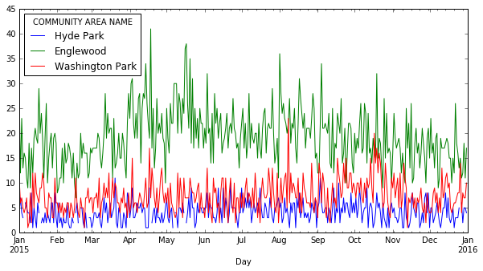

```python
community_crimes_by_day[['Hyde Park', 'Englewood', 'Washington Park']].plot(figsize=(10,5))
```

(d) By joining with the socioeconomic data, create a scatter plot of crime counts against per capita income. Summarize the relationship in words.

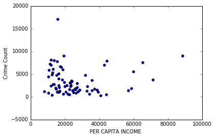

```python
crime_counts_socio = socio.merge(
        crime_counts, left_on='Community Area Number', right_index=True)
crime_counts_socio.plot(kind='scatter', x='PER CAPITA INCOME ', y='Crime Count')
```

```python
stations = pd.read_csv('Police_Stations.csv')
```

## Question 2: Community Area populations

Download the census block population data and the Community Area tracts mapping.

```python
block_populations = pd.read_csv('Population_by_2010_Census_Block.csv')
```

```python
community_tracts = pd.read_csv('community_tracts.csv')
```

(a) Join these together using the fact that the last six digits of the tract id in the mapping data correspond to the first six digits of the block id. However, the data portal has a bug: if the block starts with a zero, that digit is missing!

```python
community_tracts
```

|  | tract_id | community_id |
| --- | --- | --- |
| 0 | 17031842400 | 44 |
| 1 | 17031840300 | 59 |
| 2 | 17031841100 | 34 |
| ... | ... | ... |
| 798 | 17031130300 | 13 |
| 799 | 17031292200 | 29 |
| 800 | 17031630900 | 63 |

801 rows × 2 columns

```python
# pad with zeroes to 10 digits. there are many ways to do this
block_populations['CENSUS BLOCK'] = \
    block_populations['CENSUS BLOCK'].apply(lambda b: '%010d' % b)
# first six digits for tract
block_populations['CENSUS TRACT'] = block_populations['CENSUS BLOCK'].str[:6]
```

```python
community_tracts['CENSUS TRACT'] = \
    community_tracts.tract_id.astype(str).str[-6:]
```

(b) Calculate the total population in each Community Area.

```python
block_tract_populations = community_tracts.merge(
            block_populations, on='CENSUS TRACT')
```

```python
community_populations = pd.DataFrame({'population': block_tract_populations
            .groupby(' community_id')['TOTAL POPULATION'].sum()})
community_populations
```

| community_id | population |
| --- | --- |
| 1 | 54991 |
| 2 | 71942 |
| 3 | 56362 |
| ... | ... |
| 75 | 22544 |
| 76 | 12756 |
| 77 | 56521 |

77 rows × 1 columns

## Question 3: Crime rates

Using your answer to (2), calculate the crime rate (defined as crime count per thousand capita) for the city in 2015. Then reanswer (1a-d) with crime count replaced by crime rate. Summarize your findings in words.

(a), (b)

```python
crime_counts_population = crime_counts.merge(community_populations, left_index=True, right_index=True)
```

```python
crime_counts_population['Crime Rate'] = crime_counts_population['Crime Count'] / crime_counts_population['population']*1000
crime_counts_population_socio = crime_counts_population.merge(socio, left_index=True, right_on='Community Area Number')
```

```python
crime_counts_population_socio[['Crime Rate', 'COMMUNITY AREA NAME']].sort_values('Crime Rate')
```

|  | Crime Rate | COMMUNITY AREA NAME |
| --- | --- | --- |
| 8 | 22.704925 | Edison Park |
| 11 | 23.989626 | Forest Glen |
| 73 | 31.896507 | Mount Greenwood |
| ... | ... | ... |
| 26 | 256.673312 | East Garfield Park |
| 36 | 290.681502 | Fuller Park |
| 25 | 322.426532 | West Garfield Park |

77 rows × 2 columns

(c)

```python
community_crime_rate_by_day = community_crimes_by_day / crime_counts_population_socio.set_index('COMMUNITY AREA NAME')['population'] * 1000
```

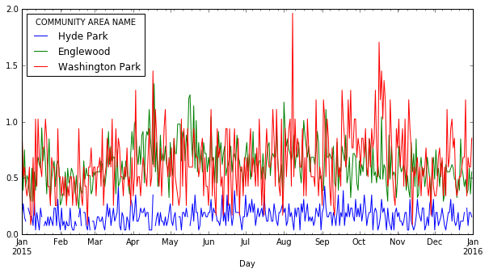

```python
community_crime_rate_by_day[['Hyde Park', 'Englewood', 'Washington Park']].plot(figsize=(10,5))
```

(d)

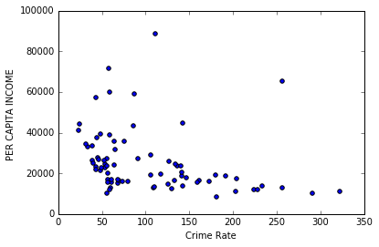

```python
crime_counts_population_socio.plot(kind='scatter', y='PER CAPITA INCOME ', x='Crime Rate')
```

## Question 4: Crime and Police Stations

Download the police stations data.

```python
stations = pd.read_csv('Police_Stations.csv')
```

(a) Extract the latitudes and longitudes of the police stations (found in the LOCATION column) as floats into their own columns called 'Station Latitude' and 'Station Longitude', respectively.

```python
stations['Station Latitude'] = stations['LOCATION'].apply(lambda l: l[l.rfind('(')+1:l.rfind(',')]).astype(float)
stations['Station Longitude'] = stations['LOCATION'].apply(lambda l: l[l.rfind(',')+1:l.rfind(')')]).astype(float)
```

(b) Join the crime data with the stations on police district. Hint: the station district is a text field (because one of them is 'Headquarters') so you'll need to convert the crime district to the same.

```python
crimes['DISTRICT'] = crimes.District.astype(str)
```

```python
crimes_stations = crimes.merge(stations, on='DISTRICT')
```

(c) Define a function which calculates the distance in kilometers between two points (latitude, longitude) using the Pythagorean theorem.

```python
def distance(row):
    return 95*( (row['Latitude']-row['Station Latitude'])**2 + (row['Longitude'] - row['Station Longitude'])**2)**.5
```

(d) Calculate the distance between each crime and its district police station.

```python
crimes_stations['Distance'] = crimes_stations.apply(distance, axis=1)
```

(e) Plot a histogram of crime count against distance to district police station. Summarize the relationship in words.

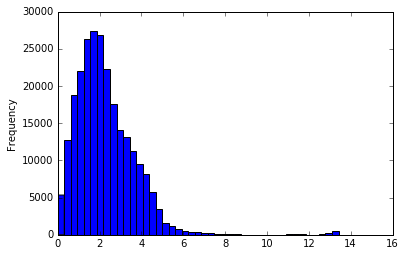

```python
crimes_stations['Distance'].plot(kind='hist', bins=50)
```